# CapstoneML_Ambiya

Ambiya Sang Aji

June 25, 2019

# Overview

Dalam project ini, penulis akan melakukan pembuatan model klasifikasi untuk data xxxx, perusahaan transportasi online dari xxxx. dalam kasus ini akan dibuat model untuk melakukan klasifikasi apakah jumlah driver di sebuah area telah memenuhi demand dari customer atau tidak, akan di klasifikasikan menjadi dua kelas, yaitu “sufficient” dan “insufficient”. variabel yang akan digunakan untuk melakukan klasifikasi adalah jumlah area dan data timestamp.

Pertama-tama akan dilakukan pengecekan terhadap data

# Read and Analyze Data

```r
scotty <- read.csv("scotty-cl-cov/data/data-train.csv")
head(scotty)
```

|  | id | trip_id | driver_id | rider_id | start_time | src_lat | src_lon | src_area | src_sub_area | dest_lat | dest_lon | dest_area | dest_sub_area | distance | status | confirmed_time_sec |
| --- | --- | --- | --- | --- | --- | --- | --- | --- | --- | --- | --- | --- | --- | --- | --- | --- |
| 1 | 59d005e1ffcfa261708ce9cd | 59d005e9cb564761a8fe5d3e | 59a892c5568be44b2734f276 | 59ad2d6efba75a581666b506 | 2017-10-01T00:00:17Z | 41.07047 | 29.01945 | sxk9 | sxk9s | 41.11716 | 29.03650 | sxk9 | sxk9u | 5.379250 | confirmed | 8 |
| 2 | 59d0066a3d32b861760d4a01 | 59d00678ffcfa261708ceb37 | 59a135565e88a24b11f11994 | 59ce930f3d32b861760a4617 | 2017-10-01T00:02:34Z | 40.94157 | 29.11484 | sxk8 | sxk8y | 41.06151 | 29.02068 | sxk9 | sxk9s | 15.497130 | confirmed | 14 |
| 3 | 59d0066affcfa261708ceb11 | NA | NA | 59cd704bcf482f6ce2fadfdb | 2017-10-01T00:02:34Z | 41.07487 | 28.99528 | sxk9 | sxk9e | 41.08351 | 29.00228 | sxk9 | sxk9e | 1.126098 | nodrivers | 0 |
| 4 | 59d006a1ffcfa261708ceba4 | 59d006c131e39c618969343d | 599dc0dfa5b4fd5471ad8453 | 59bd62cc7e3c3b663924ba86 | 2017-10-01T00:03:29Z | 41.04995 | 29.03107 | sxk9 | sxk9s | 41.04495 | 28.98192 | sxk9 | sxk9e | 4.169492 | confirmed | 32 |
| 5 | 59d006d8cb564761a8fe5efd | 59d007193d32b861760d4a77 | 59a5856573d56e7103b5d51d | 59c17cd1f6da2d274e16d0a7 | 2017-10-01T00:04:24Z | 41.05287 | 28.99522 | sxk9 | sxk9e | 41.08140 | 28.98197 | sxk9 | sxk9e | 3.358296 | confirmed | 65 |
| 6 | 59d0071cffcfa261708ced10 | 59d0078acb564761a8fe607a | 59579d5f2bde9f3c29fd0065 | 594afb1dd3841f46ad6b2a09 | 2017-10-01T00:05:32Z | 40.99332 | 28.87009 | sxk9 | sxk90 | 41.03452 | 28.97191 | sxk9 | sxk97 | 9.710550 | confirmed | 110 |

Terlihat diatas bahwa belum ada field yang menentukan apakah lokasi tersebut terdapat sufficient driver atau tidak.

Akan dilakukan pengecekan tiped data dari variabel

```r
str(scotty)
```

```
## 'data.frame':    229532 obs. of  16 variables:
##  $ id                : Factor w/ 229532 levels "59d005e1ffcfa261708ce9cd",..: 1 2 3 4 5 6 7 8 9 10 ...
##  $ trip_id           : Factor w/ 214631 levels "59d005e9cb564761a8fe5d3e",..: 1 2 NA 3 4 5 NA 6 7 8 ...
##  $ driver_id         : Factor w/ 1800 levels "58c432062eb67e3311540080",..: 618 572 NA 544 610 211 NA 861 544 144 ...
##  $ rider_id          : Factor w/ 34347 levels "58c420322eb67e3311540073",..: 10817 15812 15662 13035 13715 2975 5153 2820 13035 3574 ...
##  $ start_time        : Factor w/ 220970 levels "2017-10-01T00:00:17Z",..: 1 2 2 3 4 5 6 7 8 9 ...
##  $ src_lat           : num  41.1 40.9 41.1 41 41.1 ...
##  $ src_lon           : num  29 29.1 29 29 29 ...
##  $ src_area          : Factor w/ 3 levels "sxk3","sxk8",..: 3 2 3 3 3 3 3 3 3 3 ...
##  $ src_sub_area      : Factor w/ 86 levels "sxk31","sxk32",..: 79 53 68 79 68 55 68 73 79 72 ...
##  $ dest_lat          : num  41.1 41.1 41.1 41 41.1 ...
##  $ dest_lon          : num  29 29 29 29 29 ...
##  $ dest_area         : Factor w/ 106 levels "srt5","sryw",..: 55 55 55 55 55 55 55 55 55 55 ...
##  $ dest_sub_area     : Factor w/ 268 levels "srt51","srywc",..: 147 145 134 134 134 128 143 145 134 141 ...
##  $ distance          : num  5.38 15.5 1.13 4.17 3.36 ...
##  $ status            : Factor w/ 2 levels "confirmed","nodrivers": 1 1 2 1 1 1 2 1 1 1 ...
##  $ confirmed_time_sec: int  8 14 0 32 65 110 0 49 27 21 ...
```

Dikarenakan tipe data dari start time masih berupa factor, akan diubah menjadi timestamp

```r
scotty$start_time <- gsub("T"," ",scotty$start_time)
scotty$start_time <- gsub("Z","",scotty$start_time)
scotty$start_time <- as.POSIXct(strptime(scotty$start_time, "%Y-%m-%d %H:%M:%S"))
```

Akan dilakukan pengecekan nilai null value di variabel timestamp, src_area dan status

```r
sum(is.na(scotty$start_time))
```

```
## [1] 0
```

```r
sum(is.na(scotty$src_area))
```

```
## [1] 0
```

```r
sum(is.na(scotty$status))
```

```
## [1] 0
```

Tidak ada data N/A.

Pertama-tama akan dilakukan aggregasi data untuk dijadikan per jam terlebih dahulu

## Aggregate Data

```r
levels(scotty$src_area)
```

```
## [1] "sxk3" "sxk8" "sxk9"
```

Akan dilakukan pemisahan data per area terlebih dahulu

```r
scottyArea1 <-  scotty %>%
  select(src_area, start_time, status) %>%
  filter(src_area == "sxk3")
dummy <- dummyVars("~ status", data = scottyArea1)
dummy <- data.frame(predict(dummy, newdata = scottyArea1))
scottyArea1 <- scottyArea1[,-3]
scottyArea1 <- cbind(scottyArea1,dummy)

scottyArea1 <- scottyArea1 %>%
  mutate(date = date(start_time), hour = hour(start_time), minutes = minute(start_time)) %>%
  group_by(date,hour,src_area) %>%
  summarise(confirmed = sum(status.confirmed), nodrivers = sum(status.nodrivers))
```

```r
scottyArea2 <-  scotty %>%
  select(src_area, start_time, status) %>%
  filter(src_area == "sxk8")
dummy <- dummyVars("~ status", data = scottyArea2)
dummy <- data.frame(predict(dummy, newdata = scottyArea2))
scottyArea2 <- scottyArea2[,-3]
scottyArea2 <- cbind(scottyArea2,dummy)

scottyArea2 <- scottyArea2 %>%
  mutate(date = date(start_time), hour = hour(start_time), minutes = minute(start_time)) %>%
  group_by(date,hour,src_area) %>%
  summarise(confirmed = sum(status.confirmed), nodrivers = sum(status.nodrivers))
```

```r
scottyArea3 <-  scotty %>%
  select(src_area, start_time, status) %>%
  filter(src_area == "sxk9")
dummy <- dummyVars("~ status", data = scottyArea3)
dummy <- data.frame(predict(dummy, newdata = scottyArea3))
scottyArea3 <- scottyArea3[,-3]
scottyArea3 <- cbind(scottyArea3,dummy)

scottyArea3 <- scottyArea3 %>%
  mutate(date = date(start_time), hour = hour(start_time), minutes = minute(start_time)) %>%
  group_by(date,hour,src_area) %>%
  summarise(confirmed = sum(status.confirmed), nodrivers = sum(status.nodrivers))
```

```r
head(scottyArea1)
```

| date | hour | src_area | confirmed | nodrivers |
| --- | --- | --- | --- | --- |
| 2017-10-01 | 0 | sxk3 | 0 | 1 |
| 2017-10-01 | 1 | sxk3 | 1 | 1 |
| 2017-10-01 | 3 | sxk3 | 0 | 1 |
| 2017-10-01 | 4 | sxk3 | 0 | 1 |
| 2017-10-01 | 7 | sxk3 | 0 | 1 |
| 2017-10-01 | 8 | sxk3 | 1 | 2 |

```r
head(scottyArea2)
```

| date | hour | src_area | confirmed | nodrivers |
| --- | --- | --- | --- | --- |
| 2017-10-01 | 0 | sxk8 | 2 | 0 |
| 2017-10-01 | 12 | sxk8 | 1 | 1 |
| 2017-10-01 | 14 | sxk8 | 1 | 0 |
| 2017-10-01 | 15 | sxk8 | 3 | 2 |
| 2017-10-01 | 16 | sxk8 | 0 | 2 |
| 2017-10-01 | 17 | sxk8 | 1 | 2 |

```r
head(scottyArea3)
```

| date | hour | src_area | confirmed | nodrivers |
| --- | --- | --- | --- | --- |
| 2017-10-01 | 0 | sxk9 | 46 | 15 |
| 2017-10-01 | 1 | sxk9 | 18 | 8 |
| 2017-10-01 | 2 | sxk9 | 8 | 9 |
| 2017-10-01 | 3 | sxk9 | 3 | 4 |
| 2017-10-01 | 4 | sxk9 | 3 | 6 |
| 2017-10-01 | 5 | sxk9 | 0 | 7 |

Setelah dicek, data tersebut secara time series tidak lengkap, akan dilakukan padding dengan nilai 0. untuk melengkapi data jam yang tidak ada.

```r
scottyArea1$start_time <- paste(scottyArea1$date,scottyArea1$hour)
scottyArea1$start_time <- as.POSIXct(strptime(scottyArea1$start_time, "%Y-%m-%d %H"))
scottyArea1 <- scottyArea1[,-c(1:2)]
scottyArea2$start_time <- paste(scottyArea2$date,scottyArea2$hour)
scottyArea2$start_time <- as.POSIXct(strptime(scottyArea2$start_time, "%Y-%m-%d %H"))
scottyArea2 <- scottyArea2[,-c(1:2)]
scottyArea3$start_time <- paste(scottyArea3$date,scottyArea3$hour)
scottyArea3$start_time <- as.POSIXct(strptime(scottyArea3$start_time, "%Y-%m-%d %H"))
scottyArea3 <- scottyArea3[,-c(1:2)]
scottyArea1 <- scottyArea1 %>%
  pad() %>%
  fill_by_value()
scottyArea2 <- scottyArea2 %>%
  pad() %>%
  fill_by_value()
scottyArea3 <- scottyArea3 %>%
  pad() %>%
  fill_by_value()
scottyArea1[,1] <- "sxk3"
scottyArea2[,1] <- "sxk8"
scottyArea3[,1] <- "sxk9"
```

Setelah dilakukan padding akan dilakukan pengelompokan data sebagai sufficient atau insufficient dilihat dari jumlah nodriver di jam tersebut, dan pengelompokkan data sebelumnya di padding sebagai “sufficient”.

```r
scottyArea1 <-  scottyArea1 %>%
  mutate(percentnodrv = nodrivers/(nodrivers+confirmed), percentcfrm = confirmed/(nodrivers+confirmed)) %>%
  mutate(coverage = ifelse(percentnodrv>0,"insufficient","sufficient"))
scottyArea1[is.na(scottyArea1$percentnodrv),7] <- "sufficient"
scottyArea2 <-  scottyArea2 %>%
  mutate(percentnodrv = nodrivers/(nodrivers+confirmed), percentcfrm = confirmed/(nodrivers+confirmed)) %>%
  mutate(coverage = ifelse(percentnodrv>0,"insufficient","sufficient"))
scottyArea2[is.na(scottyArea2$percentnodrv),7] <- "sufficient"
scottyArea3 <-  scottyArea3 %>%
  mutate(percentnodrv = nodrivers/(nodrivers+confirmed), percentcfrm = confirmed/(nodrivers+confirmed)) %>%
  mutate(coverage = ifelse(percentnodrv>0,"insufficient","sufficient"))
scottyArea3[is.na(scottyArea3$percentnodrv),7] <- "sufficient"
```

Kemudian akan dilakukan penggabungan data kembali menjadi 1 dataframe, dan melihat proporsi target variabelnya.

```r
prop.table(table(scottyArea1$coverage))
```

```
##
## insufficient   sufficient
##    0.6263228    0.3736772
```

```r
prop.table(table(scottyArea2$coverage))
```

```
##
## insufficient   sufficient
##    0.1706349    0.8293651
```

```r
prop.table(table(scottyArea3$coverage))
```

```
##
## insufficient   sufficient
##    0.8260582    0.1739418
```

```r
scottys <- rbind(scottyArea1,scottyArea2, scottyArea3)
prop.table(table(scottys$coverage))
```

```
##
## insufficient   sufficient
##    0.5410053    0.4589947
```

Secara overall, kedua kelas target cukup balance

Untuk area 1 dan 3 memiliki kecenderungan driver insufficient, sedangkan untuk area 2 memiliki kecenderungan data sufficient.

Selanjutnya akan dilakukan pengecekan heatmap untuk setiap jam apakah lebih condong ke sufficient atau insufficient.

## Plot Data

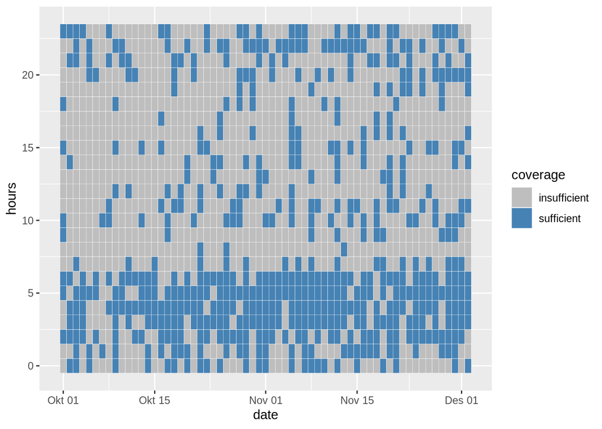

```r
scottyArea1s <- scottyArea1 %>%
  mutate(hours = hour(start_time), date = date(start_time))
ggplot(scottyArea1s, aes(x=date, y=hours)) + geom_tile(aes(fill = coverage),colour = "white") + scale_fill_manual(values = c("grey", "steelblue"))
```

Area 1 cenderung memiliki pattern insufficient di jam 06:00-24:00

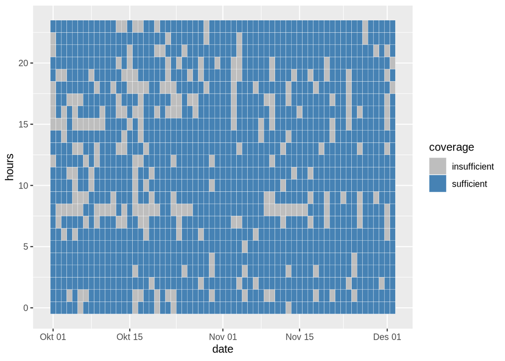

```r
scottyArea2s <- scottyArea2 %>%
  mutate(hours = hour(start_time), date = date(start_time))
ggplot(scottyArea2s, aes(x=date, y=hours)) + geom_tile(aes(fill = coverage),colour = "white") + scale_fill_manual(values = c("grey", "steelblue"))
```

Area 2 cenderung memiliki pattern insufficient secara acak.

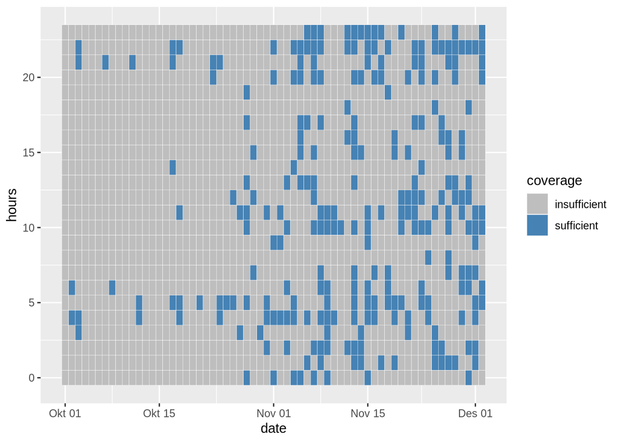

```r
scottyArea3s <- scottyArea3 %>%
  mutate(hours = hour(start_time), date = date(start_time))
ggplot(scottyArea3s, aes(x=date, y=hours)) + geom_tile(aes(fill = coverage),colour = "white") + scale_fill_manual(values = c("grey", "steelblue"))
```

Area 3 cenderung memiliki pattern insufficient di seluruh jam.

Next, akan dilakukan feature engineering, dan modelling

# Feature Engineering and Modelling

```r
scottys2 <- scottys[,-c(5,6)]
scottys2$date <- date(scottys2$start_time)
scottys2$hours <- hour(scottys2$start_time)
```

Akan dilakukan pemecahan data timestamp menjadi day, month, hour. Data year tidak akan di extract dikarenakan tujuan pembuatan model adalah melakukan prediksi klasifikasi di dalam tahun yang sama, data year tidak akan memberikan informasi yang berguna. Data tidak akan di scaling, dikarenakan data yang akan dilakukan prediksi memiliki variabel yang berisi single value, sehingga tidak bisa di scale.

```r
scottydata <- scottys2[,c("src_area","coverage","date","hours")]
scottydata$day <- day(scottydata$date)
scottydata$month <- month(scottydata$date)
scottydata <- scottydata[,-3]
scottydata$src_area <- as.factor(scottydata$src_area)
scottydata$coverage <- as.factor(scottydata$coverage)
```

## Split data

Data akan di bagi dengan rasio 65 train : 35 test

```r
set.seed(100)
id <- sample(nrow(scottydata),(nrow(scottydata)*0.65))
scottydata_train <- scottydata[id,]
scottydata_test <- scottydata[-id,]
```

Akan dibuat juga dataset yang dilakukan downsampling

Dataset dengan downsample:

```r
scottydata_train2 <- downSample(scottydata_train[,-2], scottydata_train$coverage, yname="Class")
```

## Modelling Using Logistic Regression

Pembuatan Model

```r
lr.0 <- glm(coverage ~ 1, data=scottydata_train, family="binomial")
lr.all <- glm(coverage ~ ., data=scottydata_train, family="binomial")
```

Akan dilakukan feature selection dengan menggnakan stepwise terlebih dahulu

```r
lr.bw <- step(lr.all, direction="backward")
```

```
## Start:  AIC=2987.57
## coverage ~ src_area + hours + day + month
##
##            Df Deviance    AIC
## <none>          2975.6 2987.6
## - day       1   2986.5 2996.5
## - hours     1   3015.7 3025.7
## - month     1   3057.2 3067.2
## - src_area  2   3979.1 3987.1
```

```r
flr.bt <- step(lr.0, scope = list(upper=lr.all), direction="both")
```

```
## Start:  AIC=4076.54
## coverage ~ 1
##
##            Df Deviance    AIC
## + src_area  2   3100.8 3106.8
## + month     1   4014.6 4018.6
## + hours     1   4045.9 4049.9
## <none>          4074.5 4076.5
## + day       1   4072.7 4076.7
##
## Step:  AIC=3106.84
## coverage ~ src_area
##
##            Df Deviance    AIC
## + month     1   3027.0 3035.0
## + hours     1   3061.1 3069.1
## + day       1   3096.7 3104.7
## <none>          3100.8 3106.8
## - src_area  2   4074.5 4076.5
##
## Step:  AIC=3034.99
## coverage ~ src_area + month
##
##            Df Deviance    AIC
## + hours     1   2986.5 2996.5
## + day       1   3015.7 3025.7
## <none>          3027.0 3035.0
## - month     1   3100.8 3106.8
## - src_area  2   4014.6 4018.6
##
## Step:  AIC=2996.54
## coverage ~ src_area + month + hours
##
##            Df Deviance    AIC
## + day       1   2975.6 2987.6
## <none>          2986.5 2996.5
## - hours     1   3027.0 3035.0
## - month     1   3061.1 3069.1
## - src_area  2   3985.2 3991.2
##
## Step:  AIC=2987.57
## coverage ~ src_area + month + hours + day
##
##            Df Deviance    AIC
## <none>          2975.6 2987.6
## - day       1   2986.5 2996.5
## - hours     1   3015.7 3025.7
## - month     1   3057.2 3067.2
## - src_area  2   3979.1 3987.1
```

```r
lr.fw <- step(lr.0, scope=list(lower=lr.0, upper=lr.all), direction="forward")
```

```
## Start:  AIC=4076.54
## coverage ~ 1
##
##            Df Deviance    AIC
## + src_area  2   3100.8 3106.8
## + month     1   4014.6 4018.6
## + hours     1   4045.9 4049.9
## <none>          4074.5 4076.5
## + day       1   4072.7 4076.7
##
## Step:  AIC=3106.84
## coverage ~ src_area
##
##         Df Deviance    AIC
## + month  1   3027.0 3035.0
## + hours  1   3061.1 3069.1
## + day    1   3096.7 3104.7
## <none>       3100.8 3106.8
##
## Step:  AIC=3034.99
## coverage ~ src_area + month
##
##         Df Deviance    AIC
## + hours  1   2986.5 2996.5
## + day    1   3015.7 3025.7
## <none>       3027.0 3035.0
##
## Step:  AIC=2996.54
## coverage ~ src_area + month + hours
##
##        Df Deviance    AIC
## + day   1   2975.6 2987.6
## <none>      2986.5 2996.5
##
## Step:  AIC=2987.57
## coverage ~ src_area + month + hours + day
```

Ketiga stepwise telah dicoba dan menghasilkan variabel yang sama. kemudian akan dilihat summary dari model, dalam kasus ini akan dipilih salah satu, yaitu model yang dibentuk oleh stepwise backward.

```r
summary(lr.bw)
```

```
##
## Call:
## glm(formula = coverage ~ src_area + hours + day + month, family = "binomial",
##     data = scottydata_train)
##
## Deviance Residuals:
##     Min       1Q   Median       3Q      Max
## -2.3923  -0.7769  -0.4428   0.6711   2.3246
##
## Coefficients:
##               Estimate Std. Error z value Pr(>|z|)
## (Intercept)  -8.150780   0.906827  -8.988  < 2e-16 ***
## src_areasxk8  2.242830   0.112860  19.873  < 2e-16 ***
## src_areasxk9 -1.071750   0.108787  -9.852  < 2e-16 ***
## hours        -0.041504   0.006619  -6.271 3.59e-10 ***
## day           0.016888   0.005115   3.302  0.00096 ***
## month         0.745239   0.083938   8.878  < 2e-16 ***
## ---
## Signif. codes:  0 '***' 0.001 '**' 0.01 '*' 0.05 '.' 0.1 ' ' 1
##
## (Dispersion parameter for binomial family taken to be 1)
##
##     Null deviance: 4074.5  on 2947  degrees of freedom
## Residual deviance: 2975.6  on 2942  degrees of freedom
## AIC: 2987.6
##
## Number of Fisher Scoring iterations: 4
```

Kemudian akan dilakukan pengujian model

```r
pred <- predict(lr.bw,scottydata_test[,-2], type ="response")
ypred <- ifelse(pred>0.5,1,0)
ypred <- factor(ypred, levels = c(0, 1), labels = c("insufficient", "sufficient"))
confusionMatrix(ypred, scottydata_test$coverage, positive = "insufficient")
```

```
## Confusion Matrix and Statistics
##
##               Reference
## Prediction     insufficient sufficient
##   insufficient          743        225
##   sufficient            142        478
##
##                Accuracy : 0.7689
##                  95% CI : (0.7474, 0.7894)
##     No Information Rate : 0.5573
##     P-Value [Acc > NIR] : < 2.2e-16
##
##                   Kappa : 0.5259
##
##  Mcnemar's Test P-Value : 1.866e-05
##
##             Sensitivity : 0.8395
##             Specificity : 0.6799
##          Pos Pred Value : 0.7676
##          Neg Pred Value : 0.7710
##              Prevalence : 0.5573
##          Detection Rate : 0.4679
##    Detection Prevalence : 0.6096
##       Balanced Accuracy : 0.7597
##
##        'Positive' Class : insufficient
##
```

Model menghasilkan nilai specificity yang rendah, akan dilakukan pengecekan dengan menggunakan Downsample.

## Modelling Using Logistic Regression 2 - Downsample Training Data

Pembuatan Model

```r
lr.0 <- glm(Class ~ 1, data=scottydata_train2, family="binomial")
lr.all <- glm(Class ~ ., data=scottydata_train2, family="binomial")
```

Akan dilakukan feature selection dengan menggunakan stepwise terlebih dahulu

```r
lr.bw <- step(lr.all, direction="backward")
```

```
## Start:  AIC=2792.71
## Class ~ src_area + hours + day + month
##
##            Df Deviance    AIC
## <none>          2780.7 2792.7
## - day       1   2792.2 2802.2
## - hours     1   2815.9 2825.9
## - month     1   2862.7 2872.7
## - src_area  2   3733.9 3741.9
```

```r
flr.bt <- step(lr.0, scope = list(upper=lr.all), direction="both")
```

```
## Start:  AIC=3825.4
## Class ~ 1
##
##            Df Deviance    AIC
## + src_area  2   2901.1 2907.1
## + month     1   3767.7 3771.7
## + hours     1   3798.2 3802.2
## + day       1   3820.6 3824.6
## <none>          3823.4 3825.4
##
## Step:  AIC=2907.13
## Class ~ src_area
##
##            Df Deviance    AIC
## + month     1   2827.8 2835.8
## + hours     1   2867.1 2875.1
## + day       1   2896.6 2904.6
## <none>          2901.1 2907.1
## - src_area  2   3823.4 3825.4
##
## Step:  AIC=2835.76
## Class ~ src_area + month
##
##            Df Deviance    AIC
## + hours     1   2792.2 2802.2
## + day       1   2815.9 2825.9
## <none>          2827.8 2835.8
## - month     1   2901.1 2907.1
## - src_area  2   3767.7 3771.7
##
## Step:  AIC=2802.15
## Class ~ src_area + month + hours
##
##            Df Deviance    AIC
## + day       1   2780.7 2792.7
## <none>          2792.2 2802.2
## - hours     1   2827.8 2835.8
## - month     1   2867.1 2875.1
## - src_area  2   3741.3 3747.3
##
## Step:  AIC=2792.71
## Class ~ src_area + month + hours + day
##
##            Df Deviance    AIC
## <none>          2780.7 2792.7
## - day       1   2792.2 2802.2
## - hours     1   2815.9 2825.9
## - month     1   2862.7 2872.7
## - src_area  2   3733.9 3741.9
```

```r
lr.fw <- step(lr.0, scope=list(lower=lr.0, upper=lr.all), direction="forward")
```

```
## Start:  AIC=3825.4
## Class ~ 1
##
##            Df Deviance    AIC
## + src_area  2   2901.1 2907.1
## + month     1   3767.7 3771.7
## + hours     1   3798.2 3802.2
## + day       1   3820.6 3824.6
## <none>          3823.4 3825.4
##
## Step:  AIC=2907.13
## Class ~ src_area
##
##         Df Deviance    AIC
## + month  1   2827.8 2835.8
## + hours  1   2867.1 2875.1
## + day    1   2896.6 2904.6
## <none>       2901.1 2907.1
##
## Step:  AIC=2835.76
## Class ~ src_area + month
##
##         Df Deviance    AIC
## + hours  1   2792.2 2802.2
## + day    1   2815.9 2825.9
## <none>       2827.8 2835.8
##
## Step:  AIC=2802.15
## Class ~ src_area + month + hours
##
##        Df Deviance    AIC
## + day   1   2780.7 2792.7
## <none>      2792.2 2802.2
##
## Step:  AIC=2792.71
## Class ~ src_area + month + hours + day
```

Ketiga stepwise telah dicoba dan menghasilkan variabel yang sama. kemudian akan dilihat summary dari model, dalam kasus ini akan dipilih salah satu, yaitu model yang dibentuk oleh stepwise backward.

```r
summary(lr.bw)
```

```
##
## Call:
## glm(formula = Class ~ src_area + hours + day + month, family = "binomial",
##     data = scottydata_train2)
##
## Deviance Residuals:
##      Min        1Q    Median        3Q       Max
## -2.45444  -0.79264  -0.04806   0.68050   2.28815
##
## Coefficients:
##               Estimate Std. Error z value Pr(>|z|)
## (Intercept)  -8.330629   0.940110  -8.861  < 2e-16 ***
## src_areasxk8  2.224003   0.118310  18.798  < 2e-16 ***
## src_areasxk9 -1.126727   0.111125 -10.139  < 2e-16 ***
## hours        -0.040023   0.006804  -5.882 4.05e-09 ***
## day           0.017886   0.005304   3.372 0.000746 ***
## month         0.774215   0.087209   8.878  < 2e-16 ***
## ---
## Signif. codes:  0 '***' 0.001 '**' 0.01 '*' 0.05 '.' 0.1 ' ' 1
##
## (Dispersion parameter for binomial family taken to be 1)
##
##     Null deviance: 3823.4  on 2757  degrees of freedom
## Residual deviance: 2780.7  on 2752  degrees of freedom
## AIC: 2792.7
##
## Number of Fisher Scoring iterations: 4
```

Kemudian akan dilakukan pengujian model

```r
pred <- predict(lr.bw,scottydata_test[,-2], type ="response")
ypred <- ifelse(pred>0.5,1,0)
ypred <- factor(ypred, levels = c(0, 1), labels = c("insufficient", "sufficient"))
confusionMatrix(ypred, scottydata_test$coverage, positive = "insufficient")
```

```
## Confusion Matrix and Statistics
##
##               Reference
## Prediction     insufficient sufficient
##   insufficient          712        204
##   sufficient            173        499
##
##                Accuracy : 0.7626
##                  95% CI : (0.7409, 0.7833)
##     No Information Rate : 0.5573
##     P-Value [Acc > NIR] : <2e-16
##
##                   Kappa : 0.5167
##
##  Mcnemar's Test P-Value : 0.1223
##
##             Sensitivity : 0.8045
##             Specificity : 0.7098
##          Pos Pred Value : 0.7773
##          Neg Pred Value : 0.7426
##              Prevalence : 0.5573
##          Detection Rate : 0.4484
##    Detection Prevalence : 0.5768
##       Balanced Accuracy : 0.7572
##
##        'Positive' Class : insufficient
##
```

Model menghasilkan nilai yang cukup baik ketimbang sebelum melakukan downsampling, namun masih belum sesuai harapan untuk nilai sensitivy-nya. akan dilakukan pembuatan model dengan menggunkan algoritma lain.

## Modelling using naive bayes

Pembuatan Model Naive Bayes (Untuk kebutuhan pengurangan resource knitting html untuk report, Parameter Kernel yang digunakan hanya true saja dikarenakan pparameter FALSE menghasilkan nilai yang lebih jelek dibanding TRUE)

```r
search_grid <- expand.grid(
  usekernel = c(TRUE),
  fL = 0:5,
  adjust = seq(1, 5, by = 1)
)
set.seed(100)
nvb <- train(x = scottydata_train[,-2],
               y = scottydata_train$coverage,
               method = 'nb',
               metric='ROC',
               trControl = trainControl(method = 'repeatedcv',
                                        number = 5,
                                        repeats = 3,
                                        classProbs = T,
                                        summaryFunction = twoClassSummary),
              tuneGrid = search_grid)
```

Pengecekan Iterasi Parameter Model :

```r
nvb
```

```
## Naive Bayes
##
## 2948 samples
##    4 predictor
##    2 classes: 'insufficient', 'sufficient'
##
## No pre-processing
## Resampling: Cross-Validated (5 fold, repeated 3 times)
## Summary of sample sizes: 2358, 2358, 2359, 2359, 2358, 2359, ...
## Resampling results across tuning parameters:
##
##   fL  adjust  ROC        Sens       Spec
##   0   1       0.8507465  0.8680681  0.6833544
##   0   2       0.8395018  0.8735950  0.6661950
##   0   3       0.8344298  0.8797562  0.6350162
```

[output cut: 32 more lines]

Pengujian Model

```r
nvbpredict <- predict(nvb$finalModel, scottydata_test[,-2], type="prob")
```

```r
confusionMatrix(nvbpredict$class,scottydata_test$coverage, positive = "insufficient")
```

```
## Confusion Matrix and Statistics
##
##               Reference
## Prediction     insufficient sufficient
##   insufficient          759        228
##   sufficient            126        475
##
##                Accuracy : 0.7771
##                  95% CI : (0.7558, 0.7973)
##     No Information Rate : 0.5573
##     P-Value [Acc > NIR] : < 2.2e-16
##
##                   Kappa : 0.5414
##
##  Mcnemar's Test P-Value : 7.958e-08
##
##             Sensitivity : 0.8576
##             Specificity : 0.6757
##          Pos Pred Value : 0.7690
##          Neg Pred Value : 0.7903
##              Prevalence : 0.5573
##          Detection Rate : 0.4780
##    Detection Prevalence : 0.6215
##       Balanced Accuracy : 0.7667
##
##        'Positive' Class : insufficient
##
```

## Modelling using naive bayes 2 - Downsampling Training Data

```r
search_grid <- expand.grid(
  usekernel = c(TRUE),
  fL = 0:5,
  adjust = seq(0, 5, by = 1)
)
set.seed(100)
nvb <- train(x = scottydata_train2[,-5],
               y = scottydata_train2$Class,
               method = 'nb',
               metric='ROC',
               trControl = trainControl(method = 'repeatedcv',
                                        number = 5,
                                        repeats = 3,
                                        classProbs = T,
                                        summaryFunction = twoClassSummary),
              tuneGrid = search_grid)
```

Pengecekan hasil iterasi parameter

```r
nvb
```

```
## Naive Bayes
##
## 2758 samples
##    4 predictor
##    2 classes: 'insufficient', 'sufficient'
##
## No pre-processing
## Resampling: Cross-Validated (5 fold, repeated 3 times)
## Summary of sample sizes: 2206, 2206, 2206, 2207, 2207, 2206, ...
## Resampling results across tuning parameters:
##
##   fL  adjust  ROC        Sens       Spec
##   0   0       0.5000000        NaN        NaN
##   0   1       0.8513991  0.8537585  0.7128265
##   0   2       0.8410829  0.8634238  0.6891401
```

[output cut: 38 more lines]

Pengujian Model

```r
nvbpredict <- predict(nvb$finalModel, scottydata_test[,-2], type="prob")
```

```r
confusionMatrix(nvbpredict$class,scottydata_test$coverage, positive='insufficient')
```

```
## Confusion Matrix and Statistics
##
##               Reference
## Prediction     insufficient sufficient
##   insufficient          741        186
##   sufficient            144        517
##
##                Accuracy : 0.7922
##                  95% CI : (0.7714, 0.8119)
##     No Information Rate : 0.5573
##     P-Value [Acc > NIR] : < 2e-16
##
##                   Kappa : 0.5762
##
##  Mcnemar's Test P-Value : 0.02401
##
##             Sensitivity : 0.8373
##             Specificity : 0.7354
##          Pos Pred Value : 0.7994
##          Neg Pred Value : 0.7821
##              Prevalence : 0.5573
##          Detection Rate : 0.4666
##    Detection Prevalence : 0.5838
##       Balanced Accuracy : 0.7864
##
##        'Positive' Class : insufficient
##
```

Hasil menunjukkan nilai yang lebih baik dari sebelumnya, namun untuk sensitivity masih belum mencapai target. akan dilakukan pengecekan menggunakan algoritma lain

## Modelling using Decision Tree

Pembuatan Model

```r
search_grid <- expand.grid(
mincriterion = seq(0.01, 1.0, by = 0.01)
)

trctrl <- trainControl(method = "repeatedcv", number = 5, repeats = 3, classProbs = T,summaryFunction = twoClassSummary)
set.seed(100)
dct <- train(x = scottydata_train[,-2],
                   y = scottydata_train$coverage,
                   method = "ctree",
                   trControl=trctrl,
                   tuneGrid = search_grid,
                   metric = "ROC")
```

Plot tree final model

[figure not shown]

```r
plot(dct$finalModel)
```

Pengecekan Hasil iterasi Parameter

```r
dct
```

```
## Conditional Inference Tree
##
## 2948 samples
##    4 predictor
##    2 classes: 'insufficient', 'sufficient'
##
## No pre-processing
## Resampling: Cross-Validated (5 fold, repeated 3 times)
## Summary of sample sizes: 2358, 2358, 2359, 2359, 2358, 2359, ...
## Resampling results across tuning parameters:
##
##   mincriterion  ROC        Sens       Spec
##   0.01          0.8438837  0.8210998  0.7287949
##   0.02          0.8440815  0.8253529  0.7292789
##   0.03          0.8447674  0.8281157  0.7290382
##   0.04          0.8452600  0.8296019  0.7275889
##   0.05          0.8462573  0.8338570  0.7280720
##   0.06          0.8464787  0.8370424  0.7283109
##   0.07          0.8467486  0.8368301  0.7278270
##   0.08          0.8465240  0.8368301  0.7287940
##   0.09          0.8473613  0.8378903  0.7273448
##   0.10          0.8469002  0.8385320  0.7268617
##   0.11          0.8460849  0.8387463  0.7278296
##   0.12          0.8450775  0.8395956  0.7283109
##   0.13          0.8448751  0.8402346  0.7280694
##   0.14          0.8446141  0.8402346  0.7280685
##   0.15          0.8447648  0.8421447  0.7266192
##   0.16          0.8450998  0.8425693  0.7271014
##   0.17          0.8449633  0.8432063  0.7261353
##   0.18          0.8449159  0.8434186  0.7261353
##   0.19          0.8449567  0.8436289  0.7263768
##   0.20          0.8459539  0.8429919  0.7273430
##   0.21          0.8464789  0.8434166  0.7283109
##   0.22          0.8462555  0.8463890  0.7268573
##   0.23          0.8457585  0.8478833  0.7261326
##   0.24          0.8459337  0.8500058  0.7258911
##   0.25          0.8454696  0.8497935  0.7261353
##   0.26          0.8458172  0.8497941  0.7273430
##   0.27          0.8453834  0.8497941  0.7271014
##   0.28          0.8456221  0.8504311  0.7266184
```

[output cut: 60 more lines]

```
##   0.89          0.8389141  0.8606350  0.7234774
##   0.90          0.8385602  0.8606350  0.7234774
##   0.91          0.8390587  0.8638198  0.7222697
##   0.92          0.8389039  0.8638198  0.7222697
##   0.93          0.8384277  0.8638198  0.7222697
##   0.94          0.8382654  0.8638198  0.7222697
##   0.95          0.8380039  0.8638198  0.7222697
##   0.96          0.8370775  0.8663757  0.7208204
##   0.97          0.8374115  0.8663757  0.7208204
##   0.98          0.8370721  0.8663757  0.7208204
##   0.99          0.8358491  0.8663757  0.7208204
##   1.00          0.5000000  1.0000000  0.0000000
##
## ROC was used to select the optimal model using the largest value.
## The final value used for the model was mincriterion = 0.38.
```

Pengujian Model.

```r
dctpredict2 <- predict(dct$finalModel, scottydata_test[,-2])
confusionMatrix(dctpredict2,scottydata_test$coverage,positive='insufficient')
```

```
## Confusion Matrix and Statistics
##
##               Reference
## Prediction     insufficient sufficient
##   insufficient          772        214
##   sufficient            113        489
##
##                Accuracy : 0.7941
##                  95% CI : (0.7733, 0.8137)
##     No Information Rate : 0.5573
##     P-Value [Acc > NIR] : < 2.2e-16
##
##                   Kappa : 0.5764
##
##  Mcnemar's Test P-Value : 3.202e-08
##
##             Sensitivity : 0.8723
##             Specificity : 0.6956
##          Pos Pred Value : 0.7830
##          Neg Pred Value : 0.8123
##              Prevalence : 0.5573
##          Detection Rate : 0.4861
##    Detection Prevalence : 0.6209
##       Balanced Accuracy : 0.7840
##
##        'Positive' Class : insufficient
##
```

Nilai Specitivity yang dihasilkan sedikit lagi mencapai target, dan nilai sensitivity nya melebihi target.

## Modelling using Decision Tree 2 - Downsampling Training Data

```r
search_grid <- expand.grid(
mincriterion = seq(0.01, 1, by = 0.01)
)

trctrl <- trainControl(method = "repeatedcv", number = 5, repeats = 3, classProbs = T, summaryFunction = twoClassSummary)
set.seed(100)
dct <- train(x = scottydata_train2[,-5],
                   y = scottydata_train2$Class,
                   method = "ctree",
                   trControl=trctrl,
                   tuneGrid = search_grid,
                   metric = "ROC")
```

Plot tree final model

[figure not shown]

```r
plot(dct$finalModel)
```

Pengecekan Hasil iterasi Parameter

```r
dct
```

```
## Conditional Inference Tree
##
## 2758 samples
##    4 predictor
##    2 classes: 'insufficient', 'sufficient'
##
## No pre-processing
## Resampling: Cross-Validated (5 fold, repeated 3 times)
## Summary of sample sizes: 2206, 2206, 2206, 2207, 2207, 2206, ...
## Resampling results across tuning parameters:
##
##   mincriterion  ROC        Sens       Spec
##   0.01          0.8417261  0.7957426  0.7474001
##   0.02          0.8408793  0.8003355  0.7457093
##   0.03          0.8411992  0.8049240  0.7435371
##   0.04          0.8422686  0.8044462  0.7447448
##   0.05          0.8422673  0.8049319  0.7452314
##   0.06          0.8421067  0.8078305  0.7442732
##   0.07          0.8420707  0.8119420  0.7413667
##   0.08          0.8418786  0.8136346  0.7396759
##   0.09          0.8413917  0.8129073  0.7382266
##   0.10          0.8415864  0.8138735  0.7377435
##   0.11          0.8414163  0.8133904  0.7367800
##   0.12          0.8421857  0.8162890  0.7350892
##   0.13          0.8425580  0.8177400  0.7355749
##   0.14          0.8425577  0.8199218  0.7343671
##   0.15          0.8426549  0.8233079  0.7363092
##   0.16          0.8424080  0.8233061  0.7367923
##   0.17          0.8419334  0.8230628  0.7367923
##   0.18          0.8420581  0.8233043  0.7387246
##   0.19          0.8417035  0.8225771  0.7380000
##   0.20          0.8413569  0.8233017  0.7372727
##   0.21          0.8409512  0.8228186  0.7380000
##   0.22          0.8407668  0.8230602  0.7384831
##   0.23          0.8400413  0.8252367  0.7372718
##   0.24          0.8399913  0.8252385  0.7387211
##   0.25          0.8401388  0.8247554  0.7394458
##   0.26          0.8401453  0.8245138  0.7392042
##   0.27          0.8402556  0.8252385  0.7389627
##   0.28          0.8405274  0.8254800  0.7387211
```

[output cut: 60 more lines]

```
##   0.89          0.8375495  0.8508564  0.7278314
##   0.90          0.8377127  0.8508564  0.7295222
##   0.91          0.8377127  0.8508564  0.7295222
##   0.92          0.8374568  0.8508564  0.7295222
##   0.93          0.8369802  0.8508564  0.7295222
##   0.94          0.8369504  0.8508564  0.7295222
##   0.95          0.8367727  0.8508564  0.7295222
##   0.96          0.8359695  0.8532718  0.7280676
##   0.97          0.8370309  0.8561704  0.7268599
##   0.98          0.8362644  0.8561704  0.7268599
##   0.99          0.8348763  0.8561704  0.7268599
##   1.00          0.5000000  0.8000000  0.2000000
##
## ROC was used to select the optimal model using the largest value.
## The final value used for the model was mincriterion = 0.15.
```

Pengujian Model

```r
dctpredict <- predict(dct$finalModel, scottydata_test[,-2])
confusionMatrix(dctpredict,scottydata_test$coverage,positive='insufficient')
```

```
## Confusion Matrix and Statistics
##
##               Reference
## Prediction     insufficient sufficient
##   insufficient          733        191
##   sufficient            152        512
##
##                Accuracy : 0.784
##                  95% CI : (0.7629, 0.804)
##     No Information Rate : 0.5573
##     P-Value [Acc > NIR] : < 2e-16
##
##                   Kappa : 0.5597
##
##  Mcnemar's Test P-Value : 0.04019
##
##             Sensitivity : 0.8282
##             Specificity : 0.7283
##          Pos Pred Value : 0.7933
##          Neg Pred Value : 0.7711
##              Prevalence : 0.5573
##          Detection Rate : 0.4616
##    Detection Prevalence : 0.5819
##       Balanced Accuracy : 0.7783
##
##        'Positive' Class : insufficient
##
```

Nilai specitivity meningkat dari sebelum downsampling, namun nilai sensitivity turun.

## Modelling using random forest

Pembuatan Model

```r
search_grid <- expand.grid(
mtry = seq(from = 2, to = 4, by = 1)
)

trctrl <- trainControl(method = "repeatedcv", number = 5, repeats = 3,classProbs = T, summaryFunction = twoClassSummary)
set.seed(100)
rf <- train(x = scottydata_train[,-2],
                   y = scottydata_train$coverage,
                   method = "rf",
                   trControl=trctrl,
                   tuneGrid = search_grid,
                   metric = "ROC")
```

Pengecekan Hasil iterasi parameter

```r
rf
```

```
## Random Forest
##
## 2948 samples
##    4 predictor
##    2 classes: 'insufficient', 'sufficient'
##
## No pre-processing
## Resampling: Cross-Validated (5 fold, repeated 3 times)
## Summary of sample sizes: 2358, 2358, 2359, 2359, 2358, 2359, ...
## Resampling results across tuning parameters:
##
##   mtry  ROC        Sens       Spec
##   2     0.8619662  0.8361952  0.7512736
##   3     0.8466698  0.7994336  0.7333773
##   4     0.8390660  0.7873283  0.7333720
##
## ROC was used to select the optimal model using the largest value.
## The final value used for the model was mtry = 2.
```

Pengujian Model

```r
rfpredict <- predict(rf$finalModel, scottydata_test[,-2], type = "prob")
rfpredict2 <- ifelse(rfpredict[,1] > 0.5,"insufficient","sufficient")
rfpredict2 <- as.data.frame(rfpredict2)
confusionMatrix(rfpredict2$rfpredict2,scottydata_test$coverage,positive='insufficient')
```

```
## Confusion Matrix and Statistics
##
##               Reference
## Prediction     insufficient sufficient
##   insufficient          733        181
##   sufficient            152        522
##
##                Accuracy : 0.7903
##                  95% CI : (0.7694, 0.8101)
##     No Information Rate : 0.5573
##     P-Value [Acc > NIR] : <2e-16
##
##                   Kappa : 0.5732
##
##  Mcnemar's Test P-Value : 0.1249
##
##             Sensitivity : 0.8282
##             Specificity : 0.7425
##          Pos Pred Value : 0.8020
##          Neg Pred Value : 0.7745
##              Prevalence : 0.5573
##          Detection Rate : 0.4616
##    Detection Prevalence : 0.5756
##       Balanced Accuracy : 0.7854
##
##        'Positive' Class : insufficient
##
```

Model menghasilkan nilai yang baik, namun secara sensitivity menghasilkan nilai yang belum memenuhi target.

## Modelling using Random Forest 2 - Downsampling Training Data

```r
search_grid <- expand.grid(
mtry = seq(from = 2, to = 4, by = 1)
)

trctrl <- trainControl(method = "repeatedcv", number = 5, repeats = 3,classProbs = T,summaryFunction = twoClassSummary)
set.seed(100)
rf <- train(x = scottydata_train2[,-5],
                   y = scottydata_train2$Class,
                   method = "rf",
                   trControl=trctrl,
                   tuneGrid = search_grid,
                   metric = "Sens")
```

Pengecekan hasil iterasi parameter

```r
rf
```

```
## Random Forest
##
## 2758 samples
##    4 predictor
##    2 classes: 'insufficient', 'sufficient'
##
## No pre-processing
## Resampling: Cross-Validated (5 fold, repeated 3 times)
## Summary of sample sizes: 2206, 2206, 2206, 2207, 2207, 2206, ...
## Resampling results across tuning parameters:
##
##   mtry  ROC        Sens       Spec
##   2     0.8622290  0.8230584  0.7655239
##   3     0.8477373  0.7778612  0.7602003
##   4     0.8415880  0.7609328  0.7543926
##
## Sens was used to select the optimal model using the largest value.
## The final value used for the model was mtry = 2.
```

Pengujian Model

```r
rfpredict <- predict(rf$finalModel, scottydata_test[,-2], type = "prob")
rfpredict2 <- ifelse(rfpredict[,1] > 0.5,"insufficient","sufficient")
rfpredict2 <- as.data.frame(rfpredict2)
confusionMatrix(rfpredict2$rfpredict2,scottydata_test$coverage,positive='insufficient')
```

```
## Confusion Matrix and Statistics
##
##               Reference
## Prediction     insufficient sufficient
##   insufficient          715        164
##   sufficient            170        539
##
##                Accuracy : 0.7897
##                  95% CI : (0.7688, 0.8095)
##     No Information Rate : 0.5573
##     P-Value [Acc > NIR] : <2e-16
##
##                   Kappa : 0.5741
##
##  Mcnemar's Test P-Value : 0.7844
##
##             Sensitivity : 0.8079
##             Specificity : 0.7667
##          Pos Pred Value : 0.8134
##          Neg Pred Value : 0.7602
##              Prevalence : 0.5573
##          Detection Rate : 0.4503
##    Detection Prevalence : 0.5535
##       Balanced Accuracy : 0.7873
##
##        'Positive' Class : insufficient
##
```

Niali sensitivity menurun dibandingkan dengan sebelum melakukan downsampling.

Telah dilakukan juga percobaan menggunakan package randomforest, namun tidak menghasilkan hasil yang berarti, mirip dengan menggunakan fungsi rf diatas. sehingga di take out dari laporan ini

## Modelling Using Neural Network

Melakukan Perubahan Format data sesuai dengan kebutuhan package.

```r
scottydata_trainx <- scottydata_train[,-2]
scottydata_trainy <- matrix(nrow=nrow(scottydata_train), ncol = 1)
scottydata_trainy$coverage <- scottydata_train[,2]
scottydata_testx <- scottydata_test[,-2]

dummy1 <- dummyVars("~ src_area", data = scottydata_trainx)
dummy1 <- data.frame(predict(dummy1, newdata = scottydata_trainx))

dummy2 <- dummyVars("~ src_area", data = scottydata_testx)
dummy2 <- data.frame(predict(dummy2, newdata = scottydata_testx))

dummy3 <- dummyVars("~ coverage", data = scottydata_trainy)
scottydata_trainy <- data.frame(predict(dummy3, newdata = scottydata_trainy))

scottydata_trainx <- cbind(scottydata_trainx,dummy1)
scottydata_trainx <- scottydata_trainx[,-1]

scottydata_testx <- cbind(scottydata_testx,dummy2)
scottydata_testx <- scottydata_testx[,-1]

scottydata_testx <- as.matrix(scottydata_testx)
scottydata_trainx <- as.matrix(scottydata_trainx)
scottydata_trainy <- as.matrix(scottydata_trainy)
```

Set Model (telah dilakukan percobaan beberapa konfigurasi, namun sejauh ini, konfigurasi inilah yang terbaik yang ditemukan)

```r
set.seed(100)
model <-  keras_model_sequential()
model %>%
  layer_dense(units = 128*8, activation =  "relu", input_shape =  c(6)) %>%
  layer_dropout(rate = 0.3) %>%
  layer_dense(units = 128*4, activation =  "relu") %>%
  layer_dropout(rate = 0.2) %>%
  layer_dense(units = 128*2, activation =  "relu") %>%
  layer_dropout(rate = 0.1) %>%
  layer_dense(units = 128, activation =  "relu") %>%
  layer_dropout(rate = 0.05) %>%
  layer_dense(units = 64, activation =  "relu") %>%
  layer_dense(units = 2, activation = "sigmoid")
```

Set Model Evaluasi.

```r
set.seed(100)
model %>%
  compile(
    loss = "categorical_crossentropy",
    optimizer = optimizer_adam(),
    metrics = c("accuracy")
  )
```

Fitting Model ke Data Train

```r
set.seed(100)
history <- model %>% fit(
  scottydata_trainx,scottydata_trainy,
  epochs = 40, batch_size = 907,
  validation_split = 0.2
)
```

Selanjutnya akan dilihat secara detail confusion matrixnya.

```r
predict <- model %>%  predict_classes(scottydata_testx)
```

```r
categories <- c("insufficient", "sufficient")
predict <- factor(predict, labels=categories)
confusionMatrix(predict,scottydata_test$coverage)
```

```
## Confusion Matrix and Statistics
##
##               Reference
## Prediction     insufficient sufficient
##   insufficient          744        188
##   sufficient            141        515
##
##                Accuracy : 0.7928
##                  95% CI : (0.772, 0.8125)
##     No Information Rate : 0.5573
##     P-Value [Acc > NIR] : < 2e-16
##
##                   Kappa : 0.5772
##
##  Mcnemar's Test P-Value : 0.01121
##
##             Sensitivity : 0.8407
##             Specificity : 0.7326
##          Pos Pred Value : 0.7983
##          Neg Pred Value : 0.7851
##              Prevalence : 0.5573
##          Detection Rate : 0.4685
##    Detection Prevalence : 0.5869
##       Balanced Accuracy : 0.7866
##
##        'Positive' Class : insufficient
##
```

Hasil menunujukkan nlai yang belum mencapai target.

## Modelling Using Neural Network 2 - Downsample Training Data

Melakukan Perubahan Format data sesuai dengan kebutuhan package.

```r
scottydata_trainx <- scottydata_train2[,-5]
scottydata_trainy <- matrix(nrow=nrow(scottydata_train2), ncol = 1)
scottydata_trainy$coverage <- scottydata_train2[,5]
scottydata_testx <- scottydata_test[,-2]

dummy1 <- dummyVars("~ src_area", data = scottydata_trainx)
dummy1 <- data.frame(predict(dummy1, newdata = scottydata_trainx))

dummy2 <- dummyVars("~ src_area", data = scottydata_testx)
dummy2 <- data.frame(predict(dummy2, newdata = scottydata_testx))

dummy3 <- dummyVars("~ coverage", data = scottydata_trainy)
scottydata_trainy <- data.frame(predict(dummy3, newdata = scottydata_trainy))

scottydata_trainx <- cbind(scottydata_trainx,dummy1)
scottydata_trainx <- scottydata_trainx[,-1]

scottydata_testx <- cbind(scottydata_testx,dummy2)
scottydata_testx <- scottydata_testx[,-1]

scottydata_testx <- as.matrix(scottydata_testx)
scottydata_trainx <- as.matrix(scottydata_trainx)
scottydata_trainy <- as.matrix(scottydata_trainy)
```

Set Model (telah dilakukan percobaan beberapa konfigurasi, namun sejauh ini, konfigurasi inilah yang terbaik yang ditemukan)

```r
set.seed(100)
model <-  keras_model_sequential()
model %>%
  layer_dense(units = 128*8, activation =  "relu", input_shape =  c(6)) %>%
  layer_dropout(rate = 0.3) %>%
  layer_dense(units = 128*4, activation =  "relu") %>%
  layer_dropout(rate = 0.2) %>%
  layer_dense(units = 128*2, activation =  "relu") %>%
  layer_dropout(rate = 0.1) %>%
  layer_dense(units = 128, activation =  "relu") %>%
  layer_dropout(rate = 0.05) %>%
  layer_dense(units = 64, activation =  "relu") %>%
  layer_dense(units = 2, activation = "sigmoid")
```

Set Model Evaluasi.

```r
set.seed(100)
model %>%
  compile(
    loss = "categorical_crossentropy",
    optimizer = optimizer_adam(),
    metrics = c("accuracy")
  )
```

Fitting Model ke Data Train

```r
set.seed(100)
history <- model %>% fit(
  scottydata_trainx,scottydata_trainy,
  epochs = 40, batch_size = 907,
  validation_split = 0.2
)
```

Selanjutnya akan dilihat secara detail confusion matrixnya.

```r
predict <- model %>%  predict_classes(scottydata_testx)
```

```r
categories <- c("insufficient", "sufficient")
predict <- factor(predict, labels=categories)
confusionMatrix(predict,scottydata_test$coverage)
```

```
## Confusion Matrix and Statistics
##
##               Reference
## Prediction     insufficient sufficient
##   insufficient          746        192
##   sufficient            139        511
##
##                Accuracy : 0.7916
##                  95% CI : (0.7707, 0.8113)
##     No Information Rate : 0.5573
##     P-Value [Acc > NIR] : < 2.2e-16
##
##                   Kappa : 0.5743
##
##  Mcnemar's Test P-Value : 0.004261
##
##             Sensitivity : 0.8429
##             Specificity : 0.7269
##          Pos Pred Value : 0.7953
##          Neg Pred Value : 0.7862
##              Prevalence : 0.5573
##          Detection Rate : 0.4698
##    Detection Prevalence : 0.5907
##       Balanced Accuracy : 0.7849
##
##        'Positive' Class : insufficient
##
```

```r
evaluate <- read.csv("scotty-cl-cov/data/data-submission.csv")
evaluate2 <- evaluate[,c(1:2)]
evaluate2$datetime <- gsub("T"," ",evaluate2$datetime)
evaluate2$datetime <- gsub("Z","",evaluate2$datetime)
evaluate2$datetime <- as.POSIXct(strptime(evaluate2$datetime, "%Y-%m-%d %H:%M:%S"))
evaluate2$hours <- hour(evaluate2$datetime)
evaluate2$day <- day(evaluate2$datetime)
evaluate2$month <- month(evaluate2$datetime)
evaluate2 <- evaluate2[,-2]
```

```r
cat <- dummyVars("~ src_area", data = evaluate2)
cat2 <- data.frame(predict(cat, newdata = evaluate2))
evaluate2 <- cbind(evaluate2,cat2)
evaluate2 <- evaluate2[,-1]
evaluate2 <- as.matrix(evaluate2)
predict <- model %>%  predict_classes(evaluate2)
predict2 <- model %>%  predict_proba(evaluate2)
```

```r
categories <- c("insufficient", "sufficient")
predict <- factor(predict, labels=categories)
Submission <- evaluate
Submission$coverage <- predict
Submission$insufficient <- predict2[,1]
Submission$sufficient <- predict2[,2]
```

Setaleh dilakukan pengecekan, model menghasilkan nilai : accuracy 82%, recall 86%, precision 83%, specificity 78%. milai yang sudah melewati target.

# Additional Feature Engineering

Dilakukan juga penghapusan feature month, dengan asumsi model digunakan untuk prediksi data desember (bulan 12), sedangkan data yang digunakan untuk train adalah bulan 10 dan 11. sehingga penghapusan data month seharusnya tidak terlalu berpengaruh, bahkan malah menambah hasil dari model. Setelah melakukan beberapa percobaan di beberapa algoritma dan config parameter yang berbeda, didapatkan nilai evaluasi yang melebihi target dengan menggunakan decision tree dengan data training tanpa downsampling, dengan parameter mincriterion = 0.45

```r
scottydata_train3 <- scottydata_train[,-5]
scottydata_test2 <- scottydata_test[,-5]
```

```r
search_grid <- expand.grid(
mincriterion = 0.45
)

trctrl <- trainControl(method = "repeatedcv", number = 5, repeats = 3, classProbs = T,summaryFunction = twoClassSummary)
set.seed(100)
dct <- train(x = scottydata_train3[,-2],
                   y = scottydata_train3$coverage,
                   method = "ctree",
                   trControl=trctrl,
                   tuneGrid = search_grid,
                   metric = "ROC")
```

Plot model

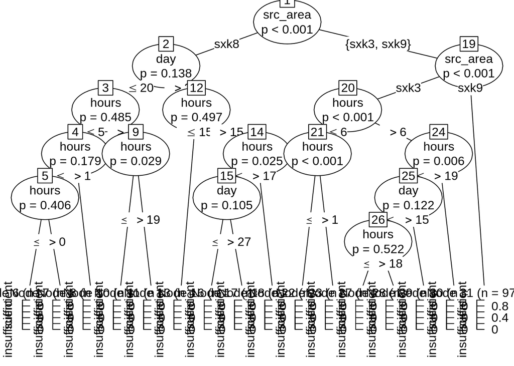

```r
plot(dct$finalModel)
```

Pengecekan result model

```r
dct
```

```
## Conditional Inference Tree
##
## 2948 samples
##    3 predictor
##    2 classes: 'insufficient', 'sufficient'
##
## No pre-processing
## Resampling: Cross-Validated (5 fold, repeated 3 times)
## Summary of sample sizes: 2358, 2358, 2359, 2359, 2358, 2359, ...
## Resampling results:
##
##   ROC        Sens      Spec
##   0.8243399  0.870622  0.7179218
##
## Tuning parameter 'mincriterion' was held constant at a value of 0.45
```

Pengujian model

```r
dctpredict <- predict(dct$finalModel, scottydata_test2[,-2], type = "response")
confusionMatrix(dctpredict,scottydata_test2$coverage,positive='insufficient')
```

```
## Confusion Matrix and Statistics
##
##               Reference
## Prediction     insufficient sufficient
##   insufficient          764        207
##   sufficient            121        496
##
##                Accuracy : 0.7935
##                  95% CI : (0.7727, 0.8131)
##     No Information Rate : 0.5573
##     P-Value [Acc > NIR] : < 2.2e-16
##
##                   Kappa : 0.5761
##
##  Mcnemar's Test P-Value : 2.688e-06
##
##             Sensitivity : 0.8633
##             Specificity : 0.7055
##          Pos Pred Value : 0.7868
##          Neg Pred Value : 0.8039
##              Prevalence : 0.5573
##          Detection Rate : 0.4811
##    Detection Prevalence : 0.6115
##       Balanced Accuracy : 0.7844
##
##        'Positive' Class : insufficient
##
```

Nilai di data test menghasilkan nilai yang lebih tinggi dari target.

```r
evaluate <- read.csv("scotty-cl-cov/data/data-submission.csv")
evaluate2 <- evaluate[,c(1:2)]
evaluate2$datetime <- gsub("T"," ",evaluate2$datetime)
evaluate2$datetime <- gsub("Z","",evaluate2$datetime)
evaluate2$datetime <- as.POSIXct(strptime(evaluate2$datetime, "%Y-%m-%d %H:%M:%S"))
evaluate2$hours <- hour(evaluate2$datetime)
evaluate2$day <- day(evaluate2$datetime)
evaluate2 <- evaluate2[,-2]
```

```r
dctpredict2 <- predict(dct$finalModel, evaluate2, type="response")
dctpredict3 <- predict(dct$finalModel, evaluate2, type="prob")
dctpredict3 <- unlist(dctpredict3)
dctpredict4 <- matrix(0L, nrow = (length(dctpredict3)/2), ncol = 2)
for (i in 1:length(dctpredict3)){
  if (i %% 2 == 0){
    dctpredict4[(i/2),2] <- dctpredict3[i]
  }
  else if (i %% 2 != 0){
  dctpredict4[(ceiling(i/2)),1] <- dctpredict3[i]
  }
}
```

```r
Submission <- evaluate
Submission$coverage <- dctpredict2
Submission$insufficient <- dctpredict4[,1]
Submission$sufficient <- dctpredict4[,2]
```

Model menghasilkan nilai accuracy 82%, precision 81%, Recall 88%, dan Specificity 75%

Telah dilakukan juga percobaan dngan menambahkan data is weekend dan is holiday, dan melakukan preprocess PCA sebelum membuat model, namun tidak ada yang mebuat hasilnya meningkat jauh, sehingga dapat dikatakan model yang dihasilkan merupakan model yang terbaik untuk kasus ini.